# Regression Models Course Project

Michael Crocco

## Motor Trend Article

### Transmission Specification and Fuel Economy

### Executive Summary:

Data is available for 32 cars from the current model year (1973-1974)

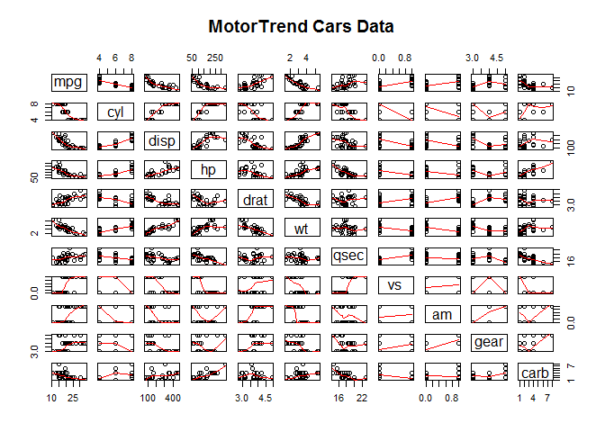

```r
data(mtcars); require(stats); require(graphics)
pairs(mtcars, panel = panel.smooth, main = "MotorTrend Cars Data")
```

Fuel Economy ($mpg$) appears to have some relationship with Transmission Type ($am$). Note: $am$ is binary and 0 represents automatic (1 is manual). So, on the surface, it would appear that manual vehicles have slightly higher $mpg$ (fuel economy). Note also that manual transmission vehicles have an inverse relationship with weight ($wt$)(they tend to weigh less than AT cars), they tend to have more gears, higher final drive ratios, lower horsepower, smaller displacement, and fewer cylinders. All of these factors should, in theory, contribute to the improvement in fuel economy.

## Explore the simple relationship between fuel economy and transmission

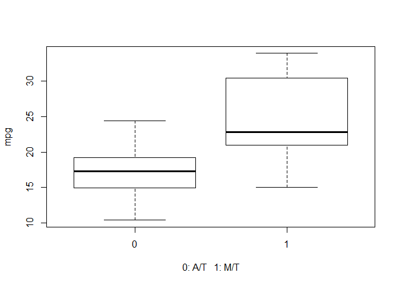

```r
boxplot(mpg ~ am, data = mtcars, xlab = "0: A/T   1: M/T", ylab = "mpg")
```

The boxplot seems to indicate a reasonable level of separation of fuel economy between manual and automatics.

## Simple Regression

A simple linear regression is conducted:

```r
fit <- lm(mpg ~ am, mtcars)
summary(fit)$coef
```

```
##              Estimate Std. Error   t value     Pr(>|t|)
## (Intercept) 17.147368   1.124603 15.247492 1.133983e-15
## am           7.244939   1.764422  4.106127 2.850207e-04
```

## Multivariable Regression and Variance Inflation Factors

Multiple nested models are created, and an Analysis of Variance Table is generated.

```r
fit2 <- lm(mpg ~ am + cyl, mtcars)
fit3 <- lm(mpg ~ am + cyl + disp, mtcars)
fit4 <- lm(mpg ~ am + cyl + disp + hp, mtcars)
fit5 <- lm(mpg ~ am + cyl + disp + hp + drat, mtcars)
fit6 <- lm(mpg ~ am + cyl + disp + hp + drat + wt, mtcars)
fit7 <- lm(mpg ~ am + cyl + disp + hp + drat + wt + qsec, mtcars)
fit8 <- lm(mpg ~ am + cyl + disp + hp + drat + wt + qsec + vs, mtcars)
fit9 <- lm(mpg ~ am + cyl + disp + hp + drat + wt + qsec + vs + gear, mtcars)
fit10 <- lm(mpg ~ am + cyl + disp + hp + drat + wt + qsec + vs + gear + carb, mtcars)
anova(fit, fit2, fit3, fit4, fit5, fit6, fit7, fit8, fit9, fit10)
```

```
## Analysis of Variance Table
##
## Model  1: mpg ~ am
## Model  2: mpg ~ am + cyl
## Model  3: mpg ~ am + cyl + disp
## Model  4: mpg ~ am + cyl + disp + hp
## Model  5: mpg ~ am + cyl + disp + hp + drat
## Model  6: mpg ~ am + cyl + disp + hp + drat + wt
## Model  7: mpg ~ am + cyl + disp + hp + drat + wt + qsec
## Model  8: mpg ~ am + cyl + disp + hp + drat + wt + qsec + vs
## Model  9: mpg ~ am + cyl + disp + hp + drat + wt + qsec + vs + gear
## Model 10: mpg ~ am + cyl + disp + hp + drat + wt + qsec + vs + gear + carb
##    Res.Df    RSS Df Sum of Sq       F    Pr(>F)
## 1      30 720.90
## 2      29 271.36  1    449.53 64.0039 8.231e-08 ***
## 3      28 252.08  1     19.28  2.7452   0.11241
## 4      27 216.37  1     35.71  5.0849   0.03493 *
## 5      26 214.50  1      1.87  0.2663   0.61121
## 6      25 162.43  1     52.06  7.4127   0.01275 *
## 7      24 149.09  1     13.34  1.8999   0.18260
## 8      23 148.87  1      0.22  0.0309   0.86214
## 9      22 147.90  1      0.97  0.1384   0.71365
## 10     21 147.49  1      0.41  0.0579   0.81218
## ---
## Signif. codes:  0 '***' 0.001 '**' 0.01 '*' 0.05 '.' 0.1 ' ' 1
```

According to the nested analysis, additional factors we should consider are: number of cylinders, horsepower, and weight. It is expected, however, that horsepower and number of cylinders are also interdependent.

```r
require(car)
semiFinalFit <- lm(mpg ~ am + cyl + hp + wt, mtcars)
vif(semiFinalFit)
```

```
##       am      cyl       hp       wt
## 2.546159 5.333685 4.310029 3.988305
```

Indeed, number of cylinders can likely be dropped from the model as it has high Variance Inflation Factor

## Final Regression Model - Diagnosis

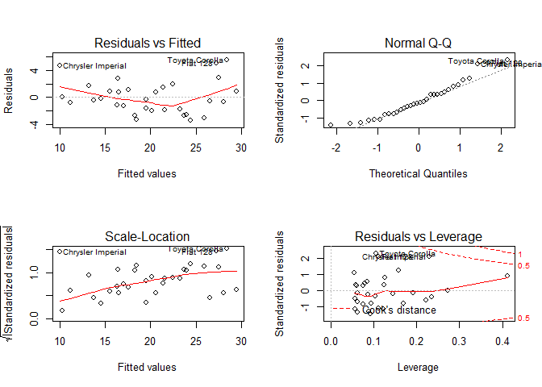

```r
fitfinal <- lm(mpg ~ am + hp + wt, mtcars)
par(mfrow = c(2,2))
plot(fitfinal)
```

The model is suitable.

```r
summary(fitfinal)$coef
```

```
##                Estimate  Std. Error   t value     Pr(>|t|)
## (Intercept) 34.00287512 2.642659337 12.866916 2.824030e-13
## am           2.08371013 1.376420152  1.513862 1.412682e-01
## hp          -0.03747873 0.009605422 -3.901830 5.464023e-04
## wt          -2.87857541 0.904970538 -3.180850 3.574031e-03
```

Our final model of fuel economy in mpg is:

$mpg = 34 + 2.08am - 0.04hp - 2.88wt$

with am as AT: 0, or MT: 1; hp in horsepower; wt in 1000lb units